# Case Study 1: Beers and Breweries

Ryan Paul

10/13/2018

```r
library(dplyr)
```

```r
library(ggplot2)
library(reshape2)
#function to trim white space
trim <- function (x) gsub("^\\s+|\\s+$", "", x)
```

# Case Study 1

## How many breweries are present in each state?

Below you can see how many “craft” breweries are in each state.

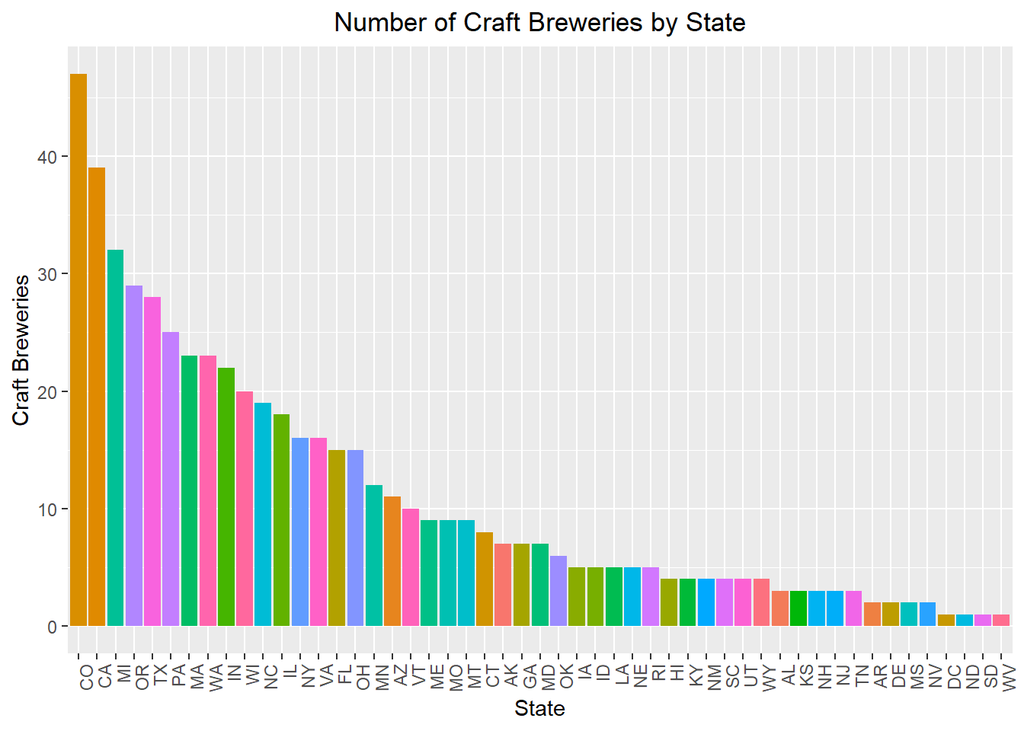

```r
#Load in the breweries data
breweryData <- read.csv("Data/Breweries.csv")
breweryData$State <- trim(breweryData$State)
#Check for empty states
breweriesWithNoState <- breweryData[is.na(breweryData$State),]
#There are none
#Group breweries by state and provide a count
stateGroupedBreweryData <- breweryData %>%
  group_by(State) %>%
  count()
#Changing column name of count
names(stateGroupedBreweryData)[2] <- "BreweriesCount"
#Creating a bar chart and ordering by states descending
stateBreweryCountBarChart <- ggplot(data=stateGroupedBreweryData,
                                    aes(x=reorder(State,-BreweriesCount), y=BreweriesCount, fill = State)) +
  geom_bar(stat="identity") +
  labs(y = "Craft Breweries", x = "State") +
  theme(axis.text.x = element_text(angle = 90, hjust = 1),
        plot.title = element_text(hjust = 0.5)) +
  ggtitle("Number of Craft Breweries by State") +
  guides(fill=FALSE) # Removing legend
stateBreweryCountBarChart
```

Merging the Beer and Brewery data sets on the Brewery ID (`Brewery_id in the beer data and Brew_ID in the brewery dataset). Once merged we open up new areas of analysis beyond just analyzing the beers or breweries and their locations on their own.

```r
beerData <- read.csv("Data/Beers.csv")
beerAndBreweryData <- merge(breweryData, beerData, by.x="Brew_ID", by.y="Brewery_id")
head(beerAndBreweryData, 6)
```

```
##   Brew_ID             Name.x        City State        Name.y Beer_ID   ABV
## 1       1 NorthGate Brewing  Minneapolis    MN       Pumpion    2689 0.060
## 2       1 NorthGate Brewing  Minneapolis    MN    Stronghold    2688 0.060
## 3       1 NorthGate Brewing  Minneapolis    MN   Parapet ESB    2687 0.056
## 4       1 NorthGate Brewing  Minneapolis    MN  Get Together    2692 0.045
## 5       1 NorthGate Brewing  Minneapolis    MN Maggie's Leap    2691 0.049
## 6       1 NorthGate Brewing  Minneapolis    MN    Wall's End    2690 0.048
##   IBU                               Style Ounces
## 1  38                         Pumpkin Ale     16
## 2  25                     American Porter     16
## 3  47 Extra Special / Strong Bitter (ESB)     16
## 4  50                        American IPA     16
## 5  26                  Milk / Sweet Stout     16
## 6  19                   English Brown Ale     16
```

```r
tail(beerAndBreweryData, 6)
```

```
##      Brew_ID                        Name.x          City State
## 2405     556         Ukiah Brewing Company         Ukiah    CA
## 2406     557       Butternuts Beer and Ale Garrattsville    NY
## 2407     557       Butternuts Beer and Ale Garrattsville    NY
## 2408     557       Butternuts Beer and Ale Garrattsville    NY
## 2409     557       Butternuts Beer and Ale Garrattsville    NY
## 2410     558 Sleeping Lady Brewing Company     Anchorage    AK
##                         Name.y Beer_ID   ABV IBU                   Style
## 2405             Pilsner Ukiah      98 0.055  NA         German Pilsener
## 2406         Porkslap Pale Ale      49 0.043  NA American Pale Ale (APA)
## 2407           Snapperhead IPA      51 0.068  NA            American IPA
## 2408         Moo Thunder Stout      50 0.049  NA      Milk / Sweet Stout
## 2409  Heinnieweisse Weissebier      52 0.049  NA              Hefeweizen
## 2410 Urban Wilderness Pale Ale      30 0.049  NA        English Pale Ale
##      Ounces
## 2405     12
## 2406     12
## 2407     12
## 2408     12
## 2409     12
## 2410     12
```

## Report the number of NA’s in each column

Running a function on all columns to create a new dataframe with columns and a count of NA values.

```r
na_count <-sapply(beerAndBreweryData, function(rowval) sum(length(which(is.na(rowval)))))
na_count <- data.frame(na_count)
na_count
```

```
##         na_count
## Brew_ID        0
## Name.x         0
## City           0
## State          0
## Name.y         0
## Beer_ID        0
## ABV           62
## IBU         1005
## Style          0
## Ounces         0
```

## Compute the median alcohol content and international bitterness unit for each state. Plot a bar chart to compare.

The data will be regrouped by state, summarized while ignoring NA values, and plotted on a barchart.

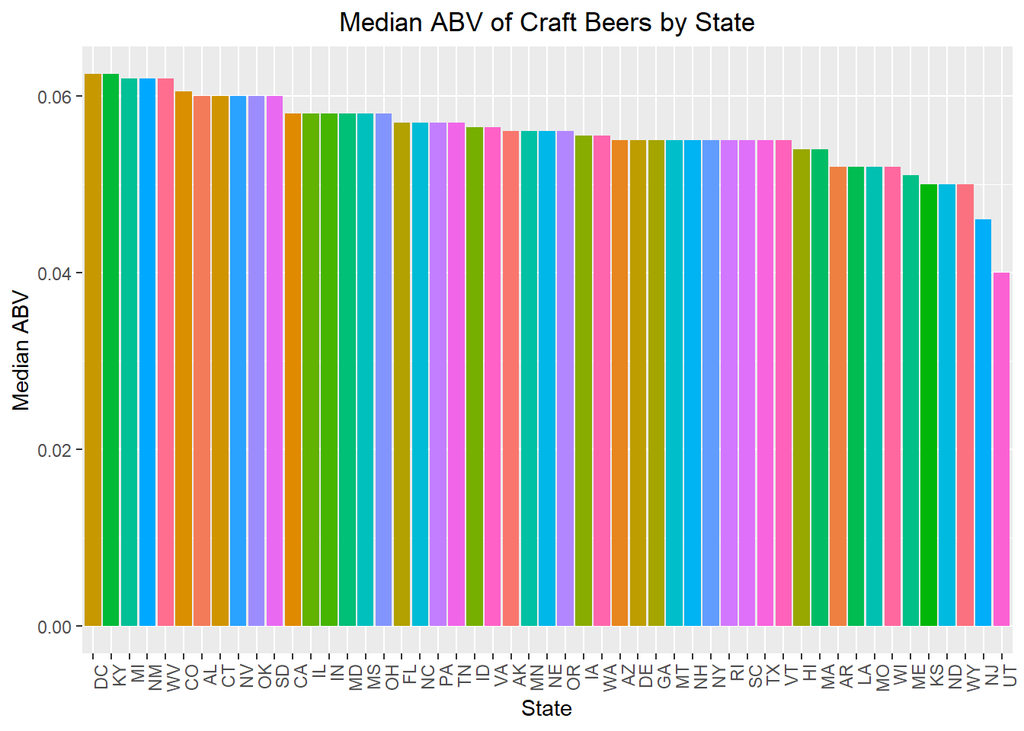

```r
#Group and summarize data, get the median of abv and ibu and ignore NA
beerSummaryByState <- beerAndBreweryData %>%
  group_by(State) %>%
  summarise(MedianABV = median(ABV, na.rm = TRUE), MedianIBU = median(IBU, na.rm = TRUE)) %>%
  as.data.frame()

#Median ABV plot, There are no NA ABVs but just in case they do in the future
medianAbvByStateBarChart <- ggplot(data=beerSummaryByState[!is.na(beerSummaryByState$MedianABV),],
                                   aes(x=reorder(State, -MedianABV), y=MedianABV, fill = State)) +
  geom_bar(stat="identity") +
  labs(y = "Median ABV", x = "State") +
  theme(axis.text.x = element_text(angle = 90, hjust = 1),
        plot.title = element_text(hjust = 0.5)) +
  ggtitle("Median ABV of Craft Beers by State") +
  guides(fill=FALSE) # Removing legend
medianAbvByStateBarChart
```

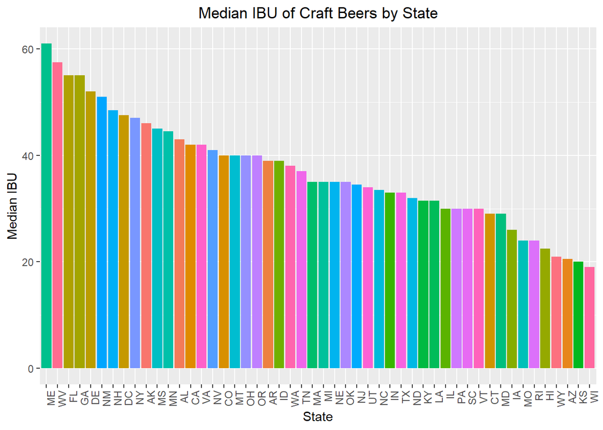

```r
#Median IBU Bar Plot. Filtering out NA removes SD
medianIbuByStateBarChart <- ggplot(data=beerSummaryByState[!is.na(beerSummaryByState$MedianIBU),] ,
                                   aes(x=reorder(State, -MedianIBU), y=MedianIBU, fill = State)) +
  geom_bar(stat="identity") +
  labs(y = "Median IBU", x = "State") +
  theme(axis.text.x = element_text(angle = 90, hjust = 1),
        plot.title = element_text(hjust = 0.5)) +
  ggtitle("Median IBU of Craft Beers by State") +
  guides(fill=FALSE) # Removing legend
medianIbuByStateBarChart
```

## Which state has the maximum alcoholic (ABV) beer? Which state has the most bitter (IBU) beer?

We will add some columns to the state summary beer data frame we have above.

[figure not shown]

```r
#resummarizing state grouped data to add max
beerSummaryByState <- beerAndBreweryData %>%
  group_by(State) %>%
  summarise(MedianABV = median(ABV, na.rm = TRUE), MedianIBU = median(IBU, na.rm = TRUE), MaxABV = max(ABV, na.rm = TRUE), MaxIBU = max(IBU, na.rm = TRUE)) %>%
  as.data.frame()
#Plot the Max ABV, running is.finite because getting the max of NA give -Int, not an issue for ABV, but just to be consistent and if the data from one state is missing like SD's IBU, i'll keep it in.
maxAbvByStateBarChart <- ggplot(data=beerSummaryByState[is.finite(beerSummaryByState$MaxABV),],
                                aes(x=reorder(State, -MaxABV), y=MaxABV, fill = State)) +
  geom_bar(stat="identity") +
  labs(y = "Max ABV (UNITS???)", x = "State") +
  theme(axis.text.x = element_text(angle = 90, hjust = 1),
        plot.title = element_text(hjust = 0.5)) +
  ggtitle("Max ABV of Craft Beers by State") +
  guides(fill=FALSE) # Removing legend
maxAbvByStateBarChart
```

[figure not shown]

```r
#Max IBU Bar Plot. Removing SD because it has -Inf for IBU
maxIbuByStateBarChart <- ggplot(data=beerSummaryByState[is.finite(beerSummaryByState$MaxIBU),] ,
                                aes(x=reorder(State, -MaxIBU), y=MaxIBU, fill = State)) +
  geom_bar(stat="identity") +
  labs(y = "Max IBU (UNITS???)", x = "State") +
  theme(axis.text.x = element_text(angle = 90, hjust = 1),
        plot.title = element_text(hjust = 0.5)) +
  ggtitle("Max IBU of Craft Beers by State") +
  guides(fill=FALSE) # Removing legend
maxIbuByStateBarChart
```

## Summary Statistics for the ABV variable

Simply running `summary` on the abv column with NAs removed.

```r
summary(beerAndBreweryData[!is.na(beerAndBreweryData$ABV),]$ABV)
```

```
##    Min. 1st Qu.  Median    Mean 3rd Qu.    Max.
## 0.00100 0.05000 0.05600 0.05977 0.06700 0.12800
```

## Is there an apparent relationship between the bitterness of the beer and its alcoholic content? Draw a scatter plot.

Making a scatter plot with IBU as the X and ABV as the Y.

[figure not shown]

```r
#Median IBU Bar Plot. Removing SD because it has NA for IBU
abvVsIbuScatterPlot <- ggplot(data=beerAndBreweryData[complete.cases(beerAndBreweryData),] ,
                              aes(x=IBU, y=ABV), fill=State) +
  geom_point(stat="identity") +
  labs(y = "IBU (UNITS???)", x = "ABV") +
  theme(axis.text.x = element_text(angle = 90, hjust = 1),
        plot.title = element_text(hjust = 0.5)) +
  ggtitle("IBU vs ABV of Craft Beers") +
  guides(fill=FALSE) # Removing legend
abvVsIbuScatterPlot
```

```r
library(kableExtra)
topStyles <- beerAndBreweryData %>%
  group_by(Style) %>%
  count()

#Changing column name of count
names(topStyles)[2] <- "Count"

topStyles <- topStyles %>%
  arrange(-Count)

knitr::kable(topStyles,, drop = FALSE) %>%
  kable_styling(full_width = F)
```

| Style | Count |
| --- | --- |
| American IPA | 424 |
| American Pale Ale (APA) | 245 |
| American Amber / Red Ale | 133 |
| American Blonde Ale | 108 |
| American Double / Imperial IPA | 105 |
| American Pale Wheat Ale | 97 |
| American Brown Ale | 70 |
| American Porter | 68 |
| Saison / Farmhouse Ale | 52 |
| Witbier | 51 |
| Fruit / Vegetable Beer | 49 |
| Kölsch | 42 |
| Hefeweizen | 40 |
| American Pale Lager | 39 |
| American Stout | 39 |
| Cider | 37 |
| American Black Ale | 36 |
| German Pilsener | 36 |
| Märzen / Oktoberfest | 30 |
| American Amber / Red Lager | 29 |
| Cream Ale | 29 |
| Czech Pilsener | 28 |
| American Pilsner | 25 |
| Belgian Pale Ale | 24 |
| Pumpkin Ale | 23 |
| Extra Special / Strong Bitter (ESB) | 20 |
| Munich Helles Lager | 20 |
| Vienna Lager | 20 |
| Scottish Ale | 19 |
| American Adjunct Lager | 18 |

[output cut: 70 more lines]